# P3

## 2. Scrape the web to get gun law information

- Let’s gather data regarding number of gun laws per state in 2017
  - source: https://statefirearmlaws.org/national-data/2017
- Potential issues with the source
  - data gathered from survey done by Boston University
  - going to have to trust the integrity of Boston University, and how they conducted the survey
- Caveats with the data
  - Since our previous data dealt with 2017, the number of gun laws data must also reflect that
  - the year restriction will limit the scope of which we can make predictions an analyze

```r
library(rvest)     #web scrapping
library(tidyr)     #web scrapping
library(stringr)   #web scrapping

#state abreviations to put into urls to scrape
states <- c('AK', 'AL', 'AR', 'AZ', 'CA', 'CO', 'CT', 'DE', 'FL', 'GA', 'HI', 'IA', 'ID', 'IL', 'IN', 'KS', 'KY', 'LA', 'MA', 'MD', 'ME', 'MI', 'MN', 'MO', 'MS', 'MT', 'NC', 'ND', 'NE', 'NH', 'NJ', 'NM', 'NV', 'NY', 'OH', 'OK', 'OR', 'PA', 'RI', 'SC', 'SD', 'TN', 'TX', 'UT', 'VA', 'VT', 'WA', 'WI', 'WV', 'WY')


##could not scrape data from original url since data is being loaded asynchronously
#url<- "https://statefirearmlaws.org/national-data/2017"


#WHEN KNITTING, CODE WOULD HANG AND TAKE FOREVER DUE TO THE WEBSITE BEING ASYNCHRONOUS (I waited for 2 hours)
#In order to avoid this, I decided to save this work I did in Rstudio to a csv
#I will upload this csv to github and pull the data from this csv
#Uncomment if(FALSE) statement in order to run and produce your own csv
if(FALSE){
  #list of all urls
  urls <- sprintf("https://statefirearmlaws.org/states/%s/2017", states)

  #knit hangs when running this, probably because this website is asynchronous
  #list of number of laws
  laws_web <- lapply(urls, function(u){
    webpage <- read_html(u)
    name <- webpage %>%
     html_nodes(".state-name-laws div") %>%
       html_text()
    # Delay calls to prevent exceeding speed limit
    Sys.sleep(1)
    return(name[1])
  })

  #knit hangs when running this, probably because this website is asynchronous
  #list of states

  states_web <- lapply(urls, function(u){
    webpage <- read_html(u)
    name <- webpage %>%
     html_nodes("h2") %>%
       html_text()
    # Delay calls to prevent exceeding speed limit
    Sys.sleep(1)
    return(name[2])
  })

  #convert format of scraped data
  states <- do.call(rbind.data.frame, states_web)
  num_laws <- do.call(rbind.data.frame, laws_web)

  #save new data into data frame
  GunLaws2017 <- data.frame("states"=states, "num_gun_laws"=num_laws)

  #change column names
  names(GunLaws2017)[1]<-"state"
  names(GunLaws2017)[2]<-"num_gun_laws"

  #convert data frame to tible
  GunLaws2017 <- as_tibble(GunLaws2017)

  #make number of gun laws numeric (tidy)
  GunLaws2017$num_gun_laws <- as.numeric(as.character(GunLaws2017$num_gun_laws))

  write.csv(GunLaws2017, file="GunLaws2017.csv")
}

GunLaws2017 <- read.csv(file="GunLaws2017.csv", header=TRUE, sep=",")
GunLaws2017 <- as_tibble(GunLaws2017)

GunLaws2017
```

```
## # A tibble: 50 x 3
##        X state       num_gun_laws
##    <int> <fct>              <int>
##  1     1 Alaska                 3
##  2     2 Alabama               10
##  3     3 Arkansas              11
##  4     4 Arizona                8
##  5     5 California           106
##  6     6 Colorado              30
##  7     7 Connecticut           92
##  8     8 Delaware              40
##  9     9 Florida               21
## 10    10 Georgia                6
## # … with 40 more rows
```

- Now, let’s plot the data to see which states have the least amount of gun laws in the USA in 2017

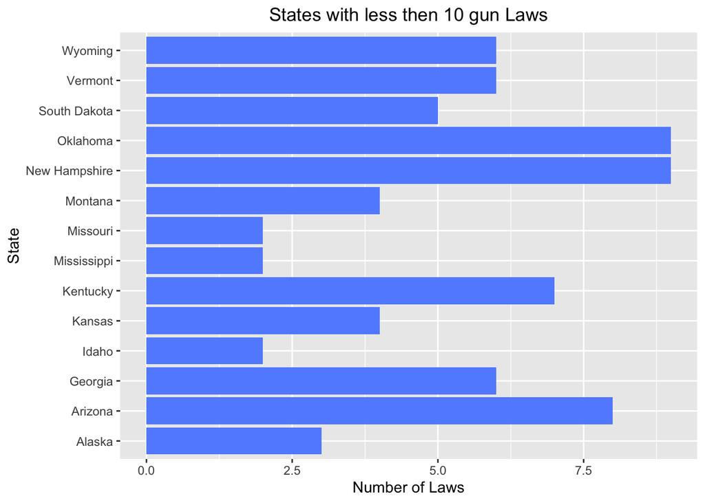

```r
#Graph the states with less then 10 gun laws
GunLaws2017 %>% filter(num_gun_laws < 10) %>% ggplot(aes(x=state, y=num_gun_laws)) +
  geom_bar(stat="identity", fill="#648FFF") +
  labs(x="State", y="Number of Laws")+
  ggtitle("States with less then 10 gun Laws")+
  coord_flip()+
  theme(plot.title = element_text(hjust=0.5))
```

- Merge the old State_Info table with the scraped data

```r
#join by state
State_Info <- State_Info %>%
                    left_join(GunLaws2017, by="state") %>%
                    select(state,num_incidents,population,num_gun_laws,num_incidents_per_capita,num_of_guns_per_capita,num_of_guns_registered,n_injured,n_killed,n_guns_involved)
State_Info
```

```
## # A tibble: 62,282 x 10
##    state num_incidents population num_gun_laws num_incidents_p… num_of_guns_per…
##    <chr>         <dbl>      <dbl>        <int>            <dbl>            <dbl>
##  1 Tenn…          1874    6715984           22         0.000279             14.8
##  2 Nebr…           439    1920076           22         0.000229             11.6
##  3 Nebr…           439    1920076           22         0.000229             11.6
##  4 Penn…          2172   12805537           37         0.000170             18.4
##  5 New …           448    2088070           10         0.000215             46.7
##  6 Virg…          1473    8470020           13         0.000174             36.3
##  7 New …           448    2088070           10         0.000215             46.7
##  8 New …           448    2088070           10         0.000215             46.7
##  9 Ohio           2701   11658609           16         0.000232             14.9
## 10 Indi…          1483    6666818           12         0.000222             17.1
## # … with 62,272 more rows, and 4 more variables: num_of_guns_registered <dbl>,
## #   n_injured <dbl>, n_killed <dbl>, n_guns_involved <dbl>
```

## 3. Modeling

- create a new model using the same variables in part two, but adding number of gun laws

```r
#must remove na values when creating lm
data_4 <- as_tibble(State_Info) %>%
  drop_na(num_of_guns_per_capita) %>%
  drop_na(num_of_guns_registered) %>%
  drop_na(num_incidents_per_capita) %>%
  drop_na(population) %>%
  drop_na(num_incidents) %>%
  drop_na(state) %>%
  drop_na(num_gun_laws)

#Partition into Train(75%) and Test(25%) sets
sample_4 <- createDataPartition(data_4$num_incidents_per_capita, p=0.75, list=FALSE)
train_4 <- data_4[sample_4, ]
test_4 <- data_4[-sample_4, ]

#create linear model
train_model_4 <- lm(formula=num_incidents_per_capita ~ num_of_guns_per_capita + num_of_guns_registered + num_incidents + population + num_gun_laws, data=train_4)

summary(train_model_4)#view our model
```

```
##
## Call:
## lm(formula = num_incidents_per_capita ~ num_of_guns_per_capita +
##     num_of_guns_registered + num_incidents + population + num_gun_laws,
##     data = train_4)
##
## Residuals:
##       Min        1Q    Median        3Q       Max
## -1.42e-04 -3.33e-05 -6.74e-06  2.36e-05  2.03e-04
##
## Coefficients:
##                         Estimate Std. Error t value Pr(>|t|)
## (Intercept)             2.08e-04   6.60e-07  315.12   <2e-16 ***
## num_of_guns_per_capita  2.52e-07   2.07e-08   12.17   <2e-16 ***
## num_of_guns_registered -9.47e-11   3.81e-12  -24.85   <2e-16 ***
## num_incidents           6.71e-08   2.44e-10  274.52   <2e-16 ***
## population             -9.89e-12   6.16e-14 -160.54   <2e-16 ***
## num_gun_laws           -1.14e-07   1.17e-08   -9.78   <2e-16 ***
## ---
## Signif. codes:  0 '***' 0.001 '**' 0.01 '*' 0.05 '.' 0.1 ' ' 1
##
## Residual standard error: 5.02e-05 on 45851 degrees of freedom
## Multiple R-squared:  0.71,   Adjusted R-squared:  0.71
## F-statistic: 2.25e+04 on 5 and 45851 DF,  p-value: <2e-16
```

- I found this to be interesting since num_gun_laws is a negative predictor
- Adding number of laws helped increase the adjusted r-squared value by .01

*Let’s see if number of gun laws has an interaction with number of incidents

```r
#must remove na values when creating lm
data_5 <- as_tibble(State_Info) %>%
  drop_na(num_of_guns_per_capita) %>%
  drop_na(num_of_guns_registered) %>%
  drop_na(num_incidents_per_capita) %>%
  drop_na(population) %>%
  drop_na(num_incidents) %>%
  drop_na(state)

#Partition into Train(75%) and Test(25%) sets
sample_5 <- createDataPartition(data_5$num_incidents_per_capita, p=0.75, list=FALSE)
train_5 <- data_5[sample_5, ]
test_5 <- data_5[-sample_5, ]

#create linear model
train_model_5 <- lm(formula=num_incidents_per_capita ~ num_of_guns_per_capita + num_of_guns_registered + num_incidents * num_gun_laws + population, data=train_5)

summary(train_model_5)#view our model
```

```
##
## Call:
## lm(formula = num_incidents_per_capita ~ num_of_guns_per_capita +
##     num_of_guns_registered + num_incidents * num_gun_laws + population,
##     data = train_5)
##
## Residuals:
##       Min        1Q    Median        3Q       Max
## -1.37e-04 -2.42e-05 -1.32e-05  2.32e-05  1.80e-04
##
## Coefficients:
##                             Estimate Std. Error t value Pr(>|t|)
## (Intercept)                 2.45e-04   8.52e-07  288.01  < 2e-16 ***
## num_of_guns_per_capita     -9.68e-08   2.00e-08   -4.84  1.3e-06 ***
## num_of_guns_registered      4.17e-11   4.14e-12   10.08  < 2e-16 ***
## num_incidents               4.92e-08   3.60e-10  136.92  < 2e-16 ***
## num_gun_laws               -8.31e-07   1.58e-08  -52.54  < 2e-16 ***
## population                 -1.22e-11   6.82e-14 -179.26  < 2e-16 ***
## num_incidents:num_gun_laws  3.85e-10   5.93e-12   64.94  < 2e-16 ***
## ---
## Signif. codes:  0 '***' 0.001 '**' 0.01 '*' 0.05 '.' 0.1 ' ' 1
##
## Residual standard error: 4.79e-05 on 45850 degrees of freedom
## Multiple R-squared:  0.736,  Adjusted R-squared:  0.736
## F-statistic: 2.13e+04 on 6 and 45850 DF,  p-value: <2e-16
```

*Now let’s look at the predictions

```r
predictions_5 <- train_model_5 %>% predict(test_5)

#R2 is the sqare & root of the correlation (between 0[no correlation] and 1[perfect correlation])
#RMSE is the standard deviation of the predicted errors
#MAE mean absolute error of the distance between the predicted and actual value
errors_5 <- data.frame(R2 = R2(predictions_5, test_5$num_incidents_per_capita),
           RMSE = RMSE(predictions_5, test_5$num_incidents_per_capita),
           MAE = MAE(predictions_5, test_5$num_incidents_per_capita))

errors_5
```

```
##        R2       RMSE        MAE
## 1 0.73878 4.7582e-05 3.4476e-05
```

- Here we can see that the R2 value is .73, making it a decent model at predicting num_incidents_per_capita
- The R2, or correlation is .73
- The RMSE, or standard deviation of the residuals is .00004
  - Meaning, our predictions are determined the have an error (in the up or down direciction) of around .00004
- The MAE, or the absolute error of the predicted error is .00003
- Now, let’s plot our predicted values vs our actual values

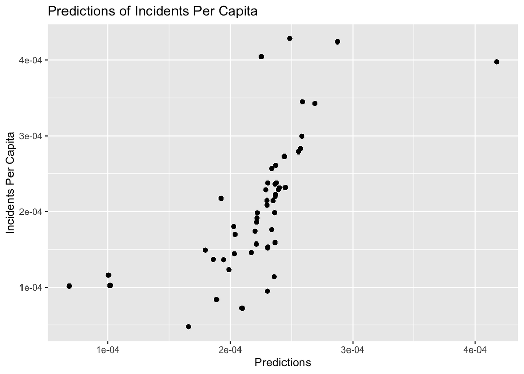

```r
ggplot(test_5, aes(x=predictions_5, y=num_incidents_per_capita), ) +
  geom_point() +
  labs(x="Predictions", y="Incidents Per Capita")+
  ggtitle("Predictions of Incidents Per Capita")
```

- Here we can see that although our results are slightly noisey, the general trend seems to be positive

*Now let’s calculate number of injured and killed per capita for each state

```r
#get total for each state
total_killed <- State_Info %>% group_by(state) %>% summarise(total_killed=sum(n_killed))
total_injured <- State_Info %>% group_by(state) %>% summarise(total_injured=sum(n_injured))

#merge results to our original table
State_Info <- State_Info %>%
                    left_join(total_killed, by="state") %>%
                    select(state,num_incidents,population,num_gun_laws,num_incidents_per_capita,num_of_guns_per_capita,num_of_guns_registered,n_injured,n_killed,n_guns_involved, total_killed)

State_Info <- State_Info %>%
                    left_join(total_injured, by="state") %>%
                    select(state,num_incidents,population,num_gun_laws,num_incidents_per_capita,num_of_guns_per_capita,num_of_guns_registered,n_injured,n_killed,n_guns_involved, total_killed, total_injured)

#calculate per capita
State_Info$num_injured_per_capita <- State_Info$total_injured/State_Info$population
State_Info$num_killed_per_capita <- State_Info$total_killed/State_Info$population

State_Info
```

```
## # A tibble: 62,282 x 14
##    state num_incidents population num_gun_laws num_incidents_p… num_of_guns_per…
##    <chr>         <dbl>      <dbl>        <int>            <dbl>            <dbl>
##  1 Tenn…          1874    6715984           22         0.000279             14.8
##  2 Nebr…           439    1920076           22         0.000229             11.6
##  3 Nebr…           439    1920076           22         0.000229             11.6
##  4 Penn…          2172   12805537           37         0.000170             18.4
##  5 New …           448    2088070           10         0.000215             46.7
##  6 Virg…          1473    8470020           13         0.000174             36.3
##  7 New …           448    2088070           10         0.000215             46.7
##  8 New …           448    2088070           10         0.000215             46.7
##  9 Ohio           2701   11658609           16         0.000232             14.9
## 10 Indi…          1483    6666818           12         0.000222             17.1
## # … with 62,272 more rows, and 8 more variables: num_of_guns_registered <dbl>,
## #   n_injured <dbl>, n_killed <dbl>, n_guns_involved <dbl>, total_killed <dbl>,
## #   total_injured <dbl>, num_injured_per_capita <dbl>,
## #   num_killed_per_capita <dbl>
```

- Now let’s graph our new data to get a better idea of what’s going on

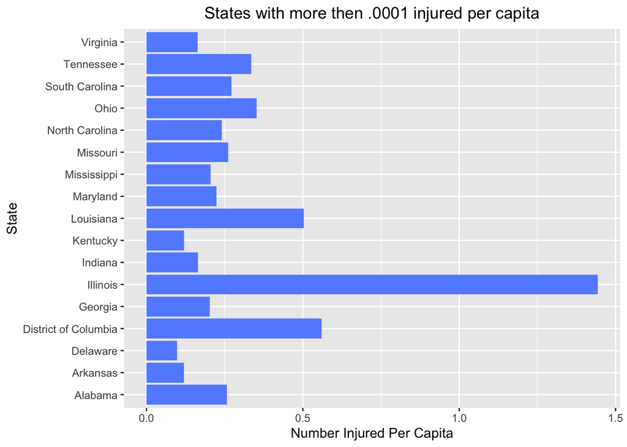

```r
State_Info %>% filter(num_injured_per_capita > .0001) %>% ggplot(aes(x=state, y=num_injured_per_capita)) +
  geom_bar(stat="identity", fill="#648FFF") +
  labs(x="State", y="Number Injured Per Capita")+
  ggtitle("States with more then .0001 injured per capita")+
  coord_flip()+
  theme(plot.title = element_text(hjust=0.5))
```

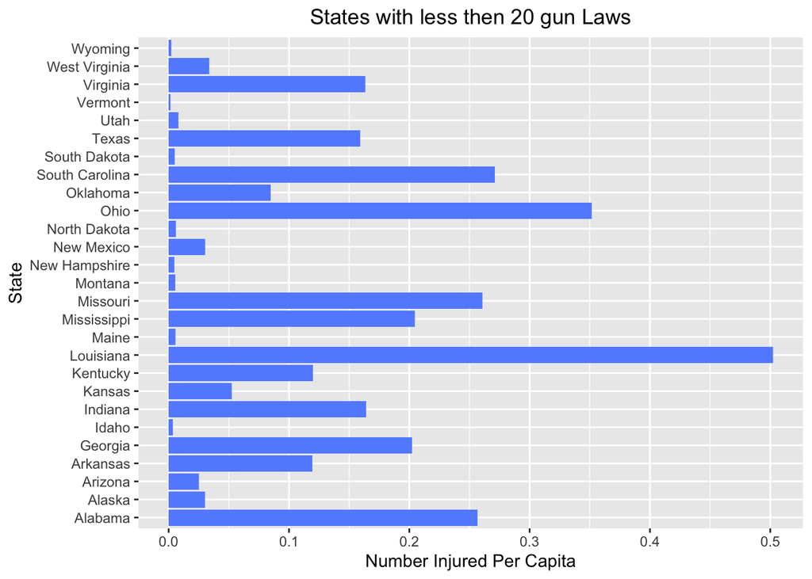

```r
State_Info %>% filter(num_gun_laws < 20) %>% ggplot(aes(x=state, y=num_injured_per_capita)) +
  geom_bar(stat="identity", fill="#648FFF") +
  labs(x="State", y="Number Injured Per Capita")+
  ggtitle("States with less then 20 gun Laws")+
  coord_flip()+
  theme(plot.title = element_text(hjust=0.5))
```

- Here we can also see that Louisiana has less then 20 gun laws
- Now let’s make a new model to predict for number of injured per capita

```r
#must remove na values when creating lm
data_6 <- as_tibble(State_Info) %>%
  drop_na(num_of_guns_per_capita) %>%
  drop_na(num_of_guns_registered) %>%
  drop_na(num_incidents_per_capita) %>%
  drop_na(population) %>%
  drop_na(num_incidents) %>%
  drop_na(state) %>%
  drop_na(total_killed) %>%
  drop_na(total_injured)%>%
  drop_na(num_injured_per_capita)

#Partition into Train(75%) and Test(25%) sets
sample_6 <- createDataPartition(data_6$num_injured_per_capita, p=0.75, list=FALSE)
train_6 <- data_6[sample_6, ]
test_6 <- data_6[-sample_6, ]

#create linear model
train_model_6 <- lm(formula=num_injured_per_capita ~  num_gun_laws + num_incidents_per_capita + num_of_guns_per_capita + num_of_guns_registered + num_incidents + population + total_injured, data=train_6)

summary(train_model_6)#view our model
```

```
##
## Call:
## lm(formula = num_injured_per_capita ~ num_gun_laws + num_incidents_per_capita +
##     num_of_guns_per_capita + num_of_guns_registered + num_incidents +
##     population + total_injured, data = train_6)
##
## Residuals:
##       Min        1Q    Median        3Q       Max
## -1.21e-04 -7.14e-06  1.84e-06  3.93e-06  4.16e-05
##
## Coefficients:
##                           Estimate Std. Error t value Pr(>|t|)
## (Intercept)              -1.89e-05   3.42e-07   -55.2   <2e-16 ***
## num_gun_laws             -1.52e-07   3.41e-09   -44.6   <2e-16 ***
## num_incidents_per_capita  5.69e-01   1.35e-03   420.0   <2e-16 ***
## num_of_guns_per_capita   -1.02e-07   5.90e-09   -17.2   <2e-16 ***
## num_of_guns_registered   -1.73e-11   1.12e-12   -15.4   <2e-16 ***
## num_incidents            -4.22e-08   2.41e-10  -175.6   <2e-16 ***
## population                1.45e-12   2.50e-14    58.0   <2e-16 ***
## total_injured             8.08e-08   2.86e-10   282.7   <2e-16 ***
## ---
## Signif. codes:  0 '***' 0.001 '**' 0.01 '*' 0.05 '.' 0.1 ' ' 1
##
## Residual standard error: 1.45e-05 on 45849 degrees of freedom
## Multiple R-squared:  0.957,  Adjusted R-squared:  0.957
## F-statistic: 1.45e+05 on 7 and 45849 DF,  p-value: <2e-16
```

```r
predictions_6 <- train_model_6 %>% predict(test_6)

#R2 is the sqare & root of the correlation (between 0[no correlation] and 1[perfect correlation])
#RMSE is the standard deviation of the predicted errors
#MAE mean absolute error of the distance between the predicted and actual value
errors_6 <- data.frame(R2 = R2(predictions_6, test_6$num_injured_per_capita),
           RMSE = RMSE(predictions_6, test_6$num_injured_per_capita),
           MAE = MAE(predictions_6, test_6$num_injured_per_capita))

errors_6
```

```
##        R2       RMSE        MAE
## 1 0.95443 1.4931e-05 9.0137e-06
```

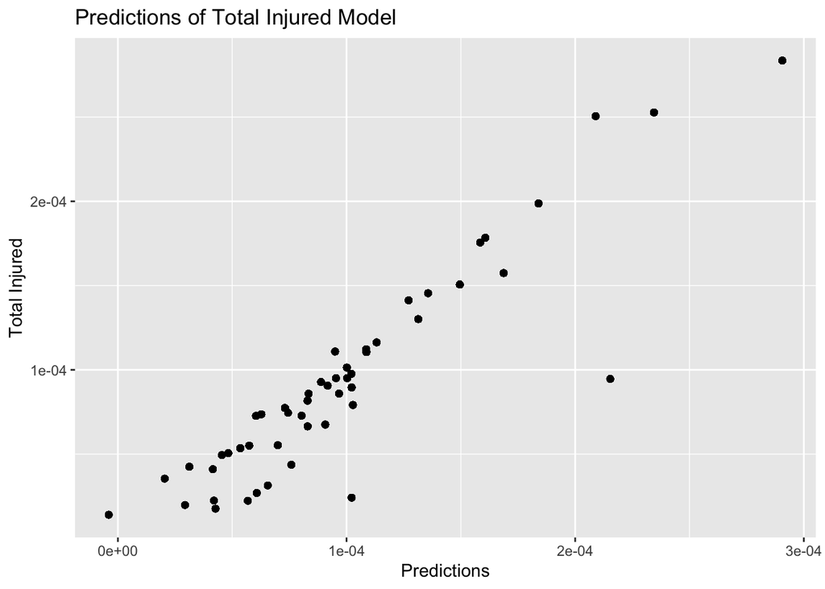

```r
ggplot(test_6, aes(x=predictions_6, y=num_injured_per_capita), ) +
  geom_point() +
  labs(x="Predictions", y="Total Injured")+
  ggtitle("Predictions of Total Injured Model")
```

- You can see a positive trend with our model

*Now let’s make another model for numer of deaths per capita

```r
#must remove na values when creating lm
data_7 <- as_tibble(State_Info) %>%
  drop_na(num_of_guns_per_capita) %>%
  drop_na(num_of_guns_registered) %>%
  drop_na(num_incidents_per_capita) %>%
  drop_na(population) %>%
  drop_na(num_incidents) %>%
  drop_na(state) %>%
  drop_na(total_killed) %>%
  drop_na(total_injured) %>%
  drop_na(num_killed_per_capita)

#Partition into Train(75%) and Test(25%) sets
sample_7 <- createDataPartition(data_7$num_killed_per_capita, p=0.75, list=FALSE)
train_7 <- data_7[sample_7, ]
test_7 <- data_7[-sample_7, ]

#create linear model
train_model_7 <- lm(formula=num_killed_per_capita ~ num_gun_laws + num_incidents_per_capita + num_of_guns_per_capita + num_of_guns_registered + num_incidents + population + total_killed, data=train_7)

summary(train_model_7)#view our model
```

```
##
## Call:
## lm(formula = num_killed_per_capita ~ num_gun_laws + num_incidents_per_capita +
##     num_of_guns_per_capita + num_of_guns_registered + num_incidents +
##     population + total_killed, data = train_7)
##
## Residuals:
##       Min        1Q    Median        3Q       Max
## -3.34e-05 -3.69e-06 -1.60e-06  4.84e-06  1.97e-05
##
## Coefficients:
##                           Estimate Std. Error t value Pr(>|t|)
## (Intercept)               1.31e-05   2.03e-07    64.4   <2e-16 ***
## num_gun_laws             -1.63e-07   2.06e-09   -79.2   <2e-16 ***
## num_incidents_per_capita  1.98e-01   8.55e-04   231.4   <2e-16 ***
## num_of_guns_per_capita    5.52e-08   3.37e-09    16.4   <2e-16 ***
## num_of_guns_registered   -6.68e-11   6.47e-13  -103.3   <2e-16 ***
## num_incidents            -1.82e-08   7.74e-11  -235.5   <2e-16 ***
## population               -9.50e-13   1.71e-14   -55.5   <2e-16 ***
## total_killed              1.15e-07   4.52e-10   254.2   <2e-16 ***
## ---
## Signif. codes:  0 '***' 0.001 '**' 0.01 '*' 0.05 '.' 0.1 ' ' 1
##
## Residual standard error: 8.11e-06 on 45848 degrees of freedom
## Multiple R-squared:  0.899,  Adjusted R-squared:  0.899
## F-statistic: 5.85e+04 on 7 and 45848 DF,  p-value: <2e-16
```

```r
predictions_7 <- train_model_7 %>% predict(test_7)

#R2 is the sqare & root of the correlation (between 0[no correlation] and 1[perfect correlation])
#RMSE is the standard deviation of the predicted errors
#MAE mean absolute error of the distance between the predicted and actual value
errors_7 <- data.frame(R2 = R2(predictions_7, test_7$num_killed_per_capita),
           RMSE = RMSE(predictions_7, test_7$num_killed_per_capita),
           MAE = MAE(predictions_7, test_7$num_killed_per_capita))

errors_7
```

```
##        R2       RMSE        MAE
## 1 0.89807 8.1386e-06 5.8551e-06
```

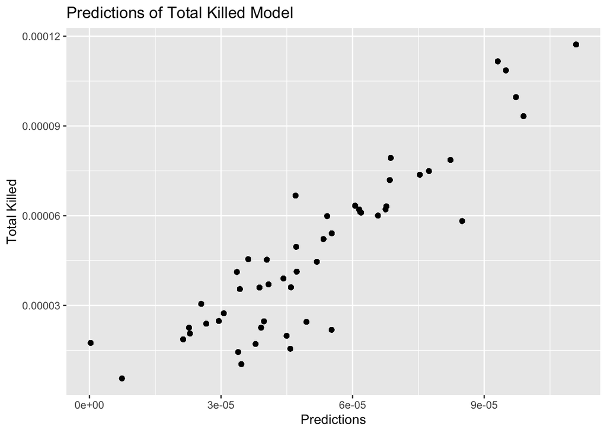

```r
ggplot(test_7, aes(x=predictions_7, y=num_killed_per_capita), ) +
  geom_point() +
  labs(x="Predictions", y="Total Killed")+
  ggtitle("Predictions of Total Killed Model")
```

- You can see a positive trend with our model
  - Not as great as our injured model, but still very good